# **Prison Break: An Intense Escape Drama**

**Author: Kacper Gruca, 456436**

**Date: 25.04.2024**

*Prison Break* is a gripping television series that revolves around the intricately planned escape of two brothers, **Michael Scofield** and **Lincoln Burrows**, from a high-security prison.

[figure not shown]

## **Plot Synopsis:**

In the heart of the narrative lies the wrongful conviction of Lincoln Burrows for the murder of the Vice President's brother. Convinced of his innocence, Michael Scofield, an ingenious structural engineer, devises an audacious plan to rescue his brother from death row.

## **Key Characters:**

- **Michael Scofield**: A brilliant mind with a hidden agenda, Michael orchestrates an elaborate escape plan by getting himself incarcerated in the same prison as his brother.
- **Lincoln Burrows**: Falsely accused and sentenced to death, Lincoln is the focal point of the series as his fate hangs in the balance.
- **Sara Tancredi**: The prison doctor who becomes entangled in Michael's plans, forming a bond with both brothers as the series progresses.

## **Themes:**

*Prison Break* explores themes of loyalty, betrayal, and the lengths one will go to for family. It delves into the complexities of the criminal justice system, raising questions about innocence, guilt, and redemption.

## **Action and Intrigue:**

The series is packed with adrenaline-pumping action sequences, intricate plot twists, and nail-biting suspense as Michael and Lincoln navigate the dangers of the prison environment while executing their daring escape plan.

## **Legacy:**

*Prison Break* has left an indelible mark on television, captivating audiences with its intense storyline and compelling characters. It continues to be celebrated for its suspenseful narrative and remains a beloved classic in the realm of prison dramas.

## **Ovveral rating 8.3/10**

The overal rating basing on the basing on the [IMDb](https://www.imdb.com/title/tt0455275/ratings/?ref_=tt_ov_rt) is 8.3.

Below is presented the bar chart with the total number of votes cast for each rating (data also acquired from IMDb).

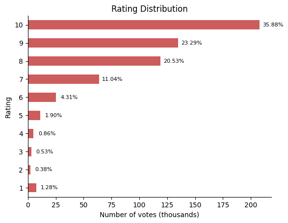

## **Viewership over time**

The data for the following part of the report were collected from [wikipedia](https://en.wikipedia.org/wiki/List_of_Prison_Break_episodes#Series_overview).

Due to the fact that there are only 5 seasons and the tables are relatively small the data was copy-pasted manually to excel.

Additionaly, a new column titled "season" was added and data has been cleaned. There were 2 NA values regarding number of views for 80 and 81 episode, so they were filled with the average number of neighboring observations for simplicity.

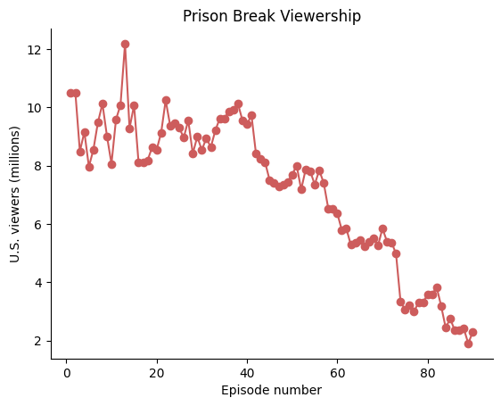

## **Season-to-season changes in viewership**

**The bar chart illustrates the trend in viewership across Seasons 1 to 5 of the serial.**

The average viewership remains relatively consistent between the first and second seasons, standing at 9.27 and 9.18 million viewers respectively. However there is a strong downward trend after the second season.

Season 3 witnesses a considerable drop in average viewership to 7.55 million, indicating a decrease of approximately 1.63 million viewers compared to the previous season.

This downward trajectory persists into the subsequent seasons, with the final season garnering an audience of 2.61 million, aligning with the observed trend.

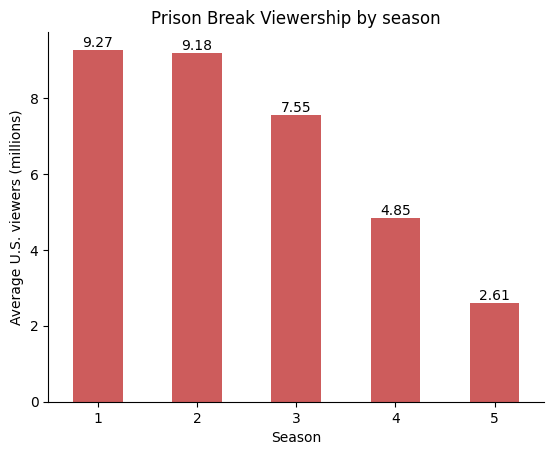